# Ecuaciones de Campo Medio

En este notebook se encuentran todas nuestras simulaciones y graficas usadas para comprobar y demostrar las ecuaciones de campo medio para nuestro sistema. Estas ecuaciones, como se explica más adelante en el notebook nos son útiles para estimar un estado del sistema a partir de un estado anterior.

```python
from modelo import *
import numpy as np
from statsmodels.nonparametric.smoothers_lowess import lowess
import math
from scipy import stats
from IPython.display import HTML, display
from mpl_toolkits.mplot3d import Axes3D
```

```python
nsimulaciones = 100
max_time=600
C=0.2
L=50
p=0.5
pr=0.1
ps=0.05
periodic = False
```

*(Para las dos simulaciones siguientes no es necesario mirar la salida, en las celdas siguientes a estas se encuentran las graficas con los resultados para una mejor visualicacion.)*

### Simulacion del sistema contando rupturas

```
Simulacion 1
Simulacion 2
Simulacion 3
Simulacion 4
Simulacion 5
Simulacion 6
Simulacion 7
Simulacion 8
Simulacion 9
Simulacion 10
Simulacion 11
Simulacion 12
Simulacion 13
Simulacion 14
Simulacion 15
Simulacion 16
Simulacion 17
Simulacion 18
Simulacion 19
Simulacion 20
Simulacion 21
Simulacion 22
Simulacion 23
Simulacion 24
Simulacion 25
Simulacion 26
Simulacion 27
Simulacion 28
Simulacion 29
Simulacion 30
Simulacion 31
Simulacion 32
Simulacion 33
Simulacion 34
Simulacion 35
Simulacion 36
Simulacion 37
Simulacion 38
Simulacion 39
Simulacion 40
```

[output cut: 45 more lines]

```
Simulacion 86
Simulacion 87
Simulacion 88
Simulacion 89
Simulacion 90
Simulacion 91
Simulacion 92
Simulacion 93
Simulacion 94
Simulacion 95
Simulacion 96
Simulacion 97
Simulacion 98
Simulacion 99
Simulacion 100
```

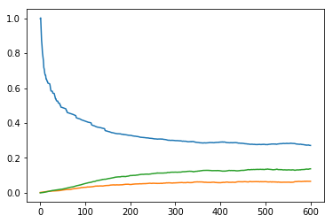

```python
np.random.seed(seed=None)  # seed for reproducibility
stats = np.array([],dtype=float)
stats2 = np.array([],dtype=float)
stats3 = np.array([],dtype=float)


tiemposBreak = []
indicesBreak = []

for n in range(0, nsimulaciones):
	print("Simulacion",str(n+1))
	evolution_infected, evolution_susceptible, evolution_recovered = simulation(max_time, C, L, p, pr, ps, periodic)
	if len(evolution_infected) < max_time:
		#indicesBreak.append(n)
		#tiemposBreak.append(len(evolution_infected))
		zeros = np.zeros((max_time+1)-len(evolution_infected))
		zeros2 = np.append(np.asarray(evolution_infected), zeros)
		evolution_infected = zeros2.tolist()

		zeros = np.zeros((max_time+1)-len(evolution_susceptible))
		zeros2 = np.append(np.asarray(evolution_susceptible), zeros)
		evolution_susceptible = zeros2.tolist()

		zeros = np.zeros((max_time+1)-len(evolution_recovered))
		zeros2 = np.append(np.asarray(evolution_recovered), zeros)
		evolution_recovered = zeros2.tolist()
	#print(evolution_infected)
	if n == 0:
		stats = np.append(stats, evolution_susceptible)
		stats2 = np.append(stats2, evolution_infected)
		stats3 = np.append(stats3, evolution_recovered)
	else:
		stats = np.vstack((stats,evolution_susceptible))
		stats2 = np.vstack((stats2,evolution_infected))
		stats3 = np.vstack((stats3,evolution_recovered))

statsTotal = np.stack((stats,stats2,stats3), axis = 0)

np.save("NEWs100t600c02l50", statsTotal)

medias = []
varianzas = []

medias = np.mean(stats, axis=0)
medias2 = np.mean(stats2, axis=0)
medias3 = np.mean(stats3, axis=0)
varianzas = np.std(stats, axis=0)


plt.plot(medias)
plt.plot(medias2)
plt.plot(medias3)
plt.show()
```

### Simulacion del sistema sin contar rupturas

```
Simulacion 1
Simulacion 1
Simulacion 2
Simulacion 2
Simulacion 3
Simulacion 4
Simulacion 4
Simulacion 5
Simulacion 6
Simulacion 7
Simulacion 7
Simulacion 7
Simulacion 8
Simulacion 8
Simulacion 8
Simulacion 9
Simulacion 9
Simulacion 10
Simulacion 10
Simulacion 11
Simulacion 11
Simulacion 11
Simulacion 12
Simulacion 13
Simulacion 14
Simulacion 15
Simulacion 15
Simulacion 15
Simulacion 16
Simulacion 17
Simulacion 18
Simulacion 19
Simulacion 20
Simulacion 20
Simulacion 21
Simulacion 22
Simulacion 23
Simulacion 23
Simulacion 23
Simulacion 23
```

[output cut: 123 more lines]

```
Simulacion 93
Simulacion 93
Simulacion 93
Simulacion 93
Simulacion 93
Simulacion 94
Simulacion 95
Simulacion 96
Simulacion 97
Simulacion 98
Simulacion 98
Simulacion 98
Simulacion 99
Simulacion 99
Simulacion 100
```

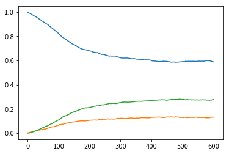

```python
np.random.seed(seed=None)  # seed for reproducibility
stats = np.array([],dtype=float)
stats2 = np.array([],dtype=float)
stats3 = np.array([],dtype=float)


tiemposBreak = []
indicesBreak = []

n = 0

while n < nsimulaciones:

    print("Simulacion",str(n+1))
    evolution_infected, evolution_susceptible, evolution_recovered = simulation(max_time, C, L, p, pr, ps)
    if len(evolution_infected) >= max_time:
      if n == 0:
        stats = np.append(stats, evolution_susceptible)
        stats2 = np.append(stats2, evolution_infected)
        stats3 = np.append(stats3, evolution_recovered)
      else:
        stats = np.vstack((stats,evolution_susceptible))
        stats2 = np.vstack((stats2,evolution_infected))
        stats3 = np.vstack((stats3,evolution_recovered))
      n += 1

statsTotal = np.stack((stats,stats2,stats3), axis = 0)

np.save("NEWESs100t600c02l50", statsTotal)

medias = []
varianzas = []

medias = np.mean(stats, axis=0)
medias2 = np.mean(stats2, axis=0)
medias3 = np.mean(stats3, axis=0)
varianzas = np.std(stats, axis=0)


plt.plot(medias)
plt.plot(medias2)
plt.plot(medias3)
plt.show()
```

### Graficas de las dos simulaciones

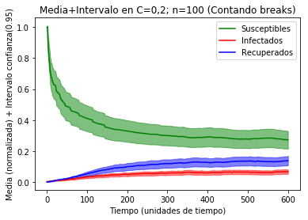

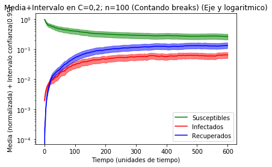

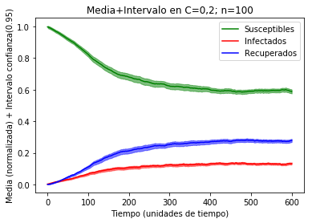

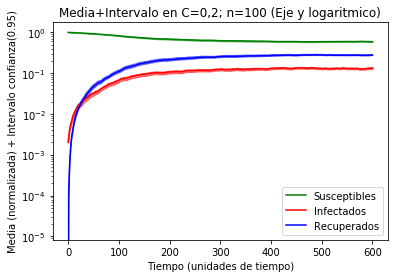

```python
from scipy.stats import distributions as dists

stats1 = collectData("NEWs100t600c02l50.npy")
stats2 = collectData("NEWESs100t600c02l50.npy")

plt.fill_between(range(stats1["s_means"].shape[0]), stats1["s_end"], stats1["s_start"], color='g', alpha=0.5)
plt.fill_between(range(stats1["i_means"].shape[0]), stats1["i_end"], stats1["i_start"], color='r', alpha=0.5)
plt.fill_between(range(stats1["r_means"].shape[0]), stats1["r_end"], stats1["r_start"], color='b', alpha=0.5)
plt.plot(stats1["s_means"], color='g')
plt.plot(stats1["i_means"], color='r')
plt.plot(stats1["r_means"], color='b')
plt.xlabel('Tiempo (unidades de tiempo)')
plt.ylabel('Media (normalizada) + Intervalo confianza(0.95)')
plt.title('Media+Intervalo en C=0,2; n=100 (Contando breaks)')
plt.legend(['Susceptibles','Infectados', 'Recuperados'])
plt.show()

plt.fill_between(range(stats1["s_means"].shape[0]), stats1["s_end"], stats1["s_start"], color='g', alpha=0.5)
plt.fill_between(range(stats1["i_means"].shape[0]), stats1["i_end"], stats1["i_start"], color='r', alpha=0.5)
plt.fill_between(range(stats1["r_means"].shape[0]), stats1["r_end"], stats1["r_start"], color='b', alpha=0.5)
plt.semilogy(stats1["s_means"], color='g')
plt.semilogy(stats1["i_means"], color='r')
plt.semilogy(stats1["r_means"], color='b')
plt.xlabel('Tiempo (unidades de tiempo)')
plt.ylabel('Media (normalizada) + Intervalo confianza(0.95)')
plt.title('Media+Intervalo en C=0,2; n=100 (Contando breaks) (Eje y logaritmico)')
plt.legend(['Susceptibles','Infectados', 'Recuperados'])
plt.show()

plt.fill_between(range(stats2["s_means"].shape[0]), stats2["s_end"], stats2["s_start"], color='g', alpha=0.5)
plt.fill_between(range(stats2["i_means"].shape[0]), stats2["i_end"], stats2["i_start"], color='r', alpha=0.5)
plt.fill_between(range(stats2["r_means"].shape[0]), stats2["r_end"], stats2["r_start"], color='b', alpha=0.5)
plt.plot(stats2["s_means"], color='g')
plt.plot(stats2["i_means"], color='r')
plt.plot(stats2["r_means"], color='b')
plt.xlabel('Tiempo (unidades de tiempo)')
plt.ylabel('Media (normalizada) + Intervalo confianza(0.95)')
plt.title('Media+Intervalo en C=0,2; n=100')
plt.legend(['Susceptibles','Infectados', 'Recuperados'])
plt.show()

plt.fill_between(range(stats2["s_means"].shape[0]), stats2["s_end"], stats2["s_start"], color='g', alpha=0.5)
plt.fill_between(range(stats2["i_means"].shape[0]), stats2["i_end"], stats2["i_start"], color='r', alpha=0.5)
plt.fill_between(range(stats2["r_means"].shape[0]), stats2["r_end"], stats2["r_start"], color='b', alpha=0.5)
plt.semilogy(stats2["s_means"], color='g')
plt.semilogy(stats2["i_means"], color='r')
plt.semilogy(stats2["r_means"], color='b')
plt.xlabel('Tiempo (unidades de tiempo)')
plt.ylabel('Media (normalizada) + Intervalo confianza(0.95)')
plt.title('Media+Intervalo en C=0,2; n=100 (Eje y logaritmico)')
plt.legend(['Susceptibles','Infectados', 'Recuperados'])
plt.show()
```

Como se puede apreciar, hay una diferencia notable entre los intervalos de confianza de cada tipo de simulación, ya que al contar los breaks, existe una mayor diferencia en el valor para el sistema en un tiempo concreto que si no contamos los breaks.

Aparte se han añadido las gráficas con el eje y logarítmico para poder apreciar la evolución de cada población de un mejor modo, ya que esto se usa cuando existen grandes diferencias entre los valores de una poblacion y otra o si los valores de un eje son muy elevados (por ejemplo, si el rango del eje va entre 0 y 100000, se podria usar para una mejor visualizacion de los datos)

# Ecuaciones de campo medio

[figure not shown]

Las ecuaciones de campo medio se basan en estimar el valor para el instante de tiempo siguiente a partir del estado actual. Estas ecuaciones están basadas en los cambios de estado de las poblaciones.

Si pasamos el término de la población que queremos calcular en el instante actual al lado izquierdo, en el lado derecho se nos queda el aumento de esta:

ð(S(t)) = -S(t)[1 - (1 - pI(t))⁴] + bR(t) ð(I(t)) = +S(t)[1 - (1 - pI(t))⁴] - aI(t) ð(R(t)) = +aI(t) - bR(t)

En el caso de los recuperados podemos ver como ambos terminos funcionan de modo lineal → probabilidad·poblacion En el caso de las otras dos poblaciones, tienen un término que funciona de forma lineal y otro que funciona de forma no lineal, en este caso:

```
                                 ±S(t)[1 - (1 - pI(t))⁴]
```

A la hora de calcular la población de susceptibles que pasan a infectados necesitamos hacer uso de ambas poblaciones, ya que para poder existir este cambio es necesario que ninguna de estas dos poblaciones sea 0.

Dentro esta expresión podemos distinguir distintas partes:

```
-(1 - pI(t)) → Nos indica la probabilidad de que un nodo infectado NO infecte a otro nodo
-(1 - pI(t))⁴ → Nos indica que esta probabilidad viene dada por 4 posibles nodos infectados vecinos a uno susceptible
-[1 - (1 - pI(t))⁴] → Nos indica la probabilidad de que un nodo sea infectado por alguno de sus cuatro vecinos
```

Multiplicando por la población de susceptibles nos encontramos como resultado la población de susceptibles que han sido infectados, por eso en ð(S(t)) es un término negativo y en ð(I(t)) como un término positivo.

### Normalizacion L·L·C

A la hora de realizar estas simulaciones, hemos añadido un nuevo parámetro "Longjump", esto lo que nos indica es que para cada instante de tiempo, nuestros nodos en el sistema, en vez de saltar a las 8 posiciones cercanas, saltará a cualquie nodo libre del sistema.

Este cambio fue necesario para poder ajustar nuestras simulaciones a los valores esperados por las ecuaciones de campo medio.

```
Simulacion 1
Simulacion 2
Simulacion 2
Simulacion 3
Simulacion 4
Simulacion 5
Simulacion 6
Simulacion 7
Simulacion 8
Simulacion 9
Simulacion 10
Simulacion 11
Simulacion 12
Simulacion 13
Simulacion 13
Simulacion 14
Simulacion 15
Simulacion 16
Simulacion 17
Simulacion 17
Simulacion 18
Simulacion 19
Simulacion 19
Simulacion 20
Simulacion 20
Simulacion 20
Simulacion 21
Simulacion 21
Simulacion 22
Simulacion 23
Simulacion 24
Simulacion 24
Simulacion 25
Simulacion 26
Simulacion 26
Simulacion 27
Simulacion 28
Simulacion 29
Simulacion 30
Simulacion 31
```

[output cut: 74 more lines]

```
Simulacion 88
Simulacion 89
Simulacion 90
Simulacion 91
Simulacion 92
Simulacion 93
Simulacion 93
Simulacion 94
Simulacion 95
Simulacion 96
Simulacion 97
Simulacion 98
Simulacion 99
Simulacion 99
Simulacion 100
```

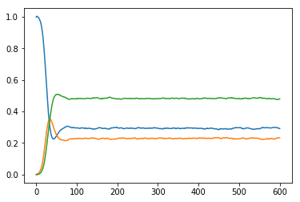

```python
nsimulaciones = 100
max_time=600
C=0.2
L=50
p=0.5
pr=0.1
ps=0.05
periodic = False
longjump = True

np.random.seed(seed=None)  # seed for reproducibility
stats = np.array([],dtype=float)
stats2 = np.array([],dtype=float)
stats3 = np.array([],dtype=float)


tiemposBreak = []
indicesBreak = []

n = 0

while n < nsimulaciones:

    print("Simulacion",str(n+1))
    evolution_infected, evolution_susceptible, evolution_recovered = simulation(max_time, C, L, p, pr, ps, periodic, longjump)
    if len(evolution_infected) >= max_time:
      if n == 0:
        stats = np.append(stats, evolution_susceptible)
        stats2 = np.append(stats2, evolution_infected)
        stats3 = np.append(stats3, evolution_recovered)
      else:
        stats = np.vstack((stats,evolution_susceptible))
        stats2 = np.vstack((stats2,evolution_infected))
        stats3 = np.vstack((stats3,evolution_recovered))
      n += 1

statsTotal = np.stack((stats,stats2,stats3), axis = 0)

np.save("NEWESs100t600c02l50LJ", statsTotal)

medias = []
varianzas = []

medias = np.mean(stats, axis=0)
medias2 = np.mean(stats2, axis=0)
medias3 = np.mean(stats3, axis=0)
varianzas = np.std(stats, axis=0)


plt.plot(medias)
plt.plot(medias2)
plt.plot(medias3)
plt.show()
```

### Salida de nuestra simulacion para campo medio con normalizacion L·L·C

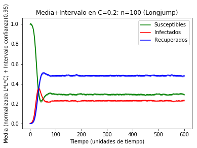

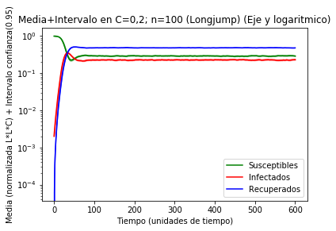

```python
from scipy.stats import distributions as dists
stats3 = collectData("NEWESs100t600c02l50LJ.npy")

plt.fill_between(range(stats3["s_means"].shape[0]), stats3["s_end"], stats3["s_start"], color='g', alpha=0.5)
plt.fill_between(range(stats3["i_means"].shape[0]), stats3["i_end"], stats3["i_start"], color='r', alpha=0.5)
plt.fill_between(range(stats3["r_means"].shape[0]), stats3["r_end"], stats3["r_start"], color='b', alpha=0.5)
plt.plot(stats3["s_means"], color='g')
plt.plot(stats3["i_means"], color='r')
plt.plot(stats3["r_means"], color='b')
plt.xlabel('Tiempo (unidades de tiempo)')
plt.ylabel('Media (normalizada L*L*C) + Intervalo confianza(0.95)')
plt.title('Media+Intervalo en C=0,2; n=100 (Longjump)')
plt.legend(['Susceptibles','Infectados', 'Recuperados'])
plt.show()

plt.fill_between(range(stats3["s_means"].shape[0]), stats3["s_end"], stats3["s_start"], color='g', alpha=0.5)
plt.fill_between(range(stats3["i_means"].shape[0]), stats3["i_end"], stats3["i_start"], color='r', alpha=0.5)
plt.fill_between(range(stats3["r_means"].shape[0]), stats3["r_end"], stats3["r_start"], color='b', alpha=0.5)
plt.semilogy(stats3["s_means"], color='g')
plt.semilogy(stats3["i_means"], color='r')
plt.semilogy(stats3["r_means"], color='b')
plt.xlabel('Tiempo (unidades de tiempo)')
plt.ylabel('Media (normalizada L*L*C) + Intervalo confianza(0.95)')
plt.title('Media+Intervalo en C=0,2; n=100 (Longjump) (Eje y logaritmico)')
plt.legend(['Susceptibles','Infectados', 'Recuperados'])
plt.show()
```

### Comparacion de nuestra simulacion para campo medio con normalizacion L·L·C

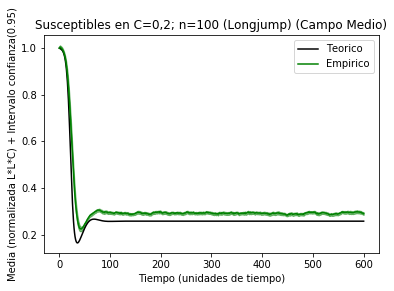

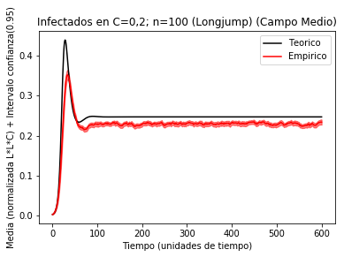

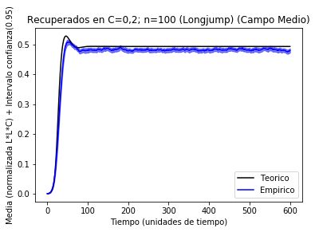

```python
L = 50
C = 0.2
a = pr
b = ps

Saux = [((L*L*C)-1)/(L*L)]
Iaux = [1/(L*L)]
Raux = [0]

for t in range(0, max_time):
    Saux.append(Saux[t] - Saux[t]*(1-(1-p*Iaux[t])**4) + b*Raux[t])

    Iaux.append(Iaux[t] + Saux[t]*(1-(1-p*Iaux[t])**4) - a*Iaux[t])

    Raux.append(Raux[t] + a*Iaux[t] - b*Raux[t])

S = []
I = []
R = []

for i in Saux:
    S.append((i*L*L)/(L*L*C))
for i in Iaux:
    I.append((i*L*L)/(L*L*C))
for i in Raux:
    R.append((i*L*L)/(L*L*C))

plt.plot(S, "k")
plt.fill_between(range(stats3["s_means"].shape[0]), stats3["s_end"], stats3["s_start"], color='g', alpha=0.5)
plt.plot(stats3["s_means"], color='g')
plt.xlabel('Tiempo (unidades de tiempo)')
plt.ylabel('Media (normalizada L*L*C) + Intervalo confianza(0.95)')
plt.title('Susceptibles en C=0,2; n=100 (Longjump) (Campo Medio)')
plt.legend(['Teorico','Empirico'])
plt.show()

plt.plot(I, "k")
plt.fill_between(range(stats3["i_means"].shape[0]), stats3["i_end"], stats3["i_start"], color='r', alpha=0.5)
plt.plot(stats3["i_means"], color='r')
plt.xlabel('Tiempo (unidades de tiempo)')
plt.ylabel('Media (normalizada L*L*C) + Intervalo confianza(0.95)')
plt.title('Infectados en C=0,2; n=100 (Longjump) (Campo Medio)')
plt.legend(['Teorico','Empirico'])
plt.show()

plt.plot(R, "k")
plt.fill_between(range(stats3["r_means"].shape[0]), stats3["r_end"], stats3["r_start"], color='b', alpha=0.5)
plt.plot(stats3["r_means"], color='b')
plt.xlabel('Tiempo (unidades de tiempo)')
plt.ylabel('Media (normalizada L*L*C) + Intervalo confianza(0.95)')
plt.title('Recuperados en C=0,2; n=100 (Longjump) (Campo Medio)')
plt.legend(['Teorico','Empirico'])
plt.show()
```

Como se puede apreciar, la forma de la salida de nuestra simulación es muy similar a la forma de las gráficas de las ecuaciones de campo medio. Pero, existe un error en la zona estacionaria del sistema, donde nuestros valores tienen una separacion con lo ideal algo grande.

Para intentar arreglarlo hemos seguido varios métodos, el primero de todos es cambiar la normalización usada a la que usan en el paper. Es decir, no usar L·L·C y usar L·L.

### Normalizacion LL

```
Simulacion 1
Simulacion 2
Simulacion 3
Simulacion 3
Simulacion 4
Simulacion 5
Simulacion 6
Simulacion 7
Simulacion 8
Simulacion 9
Simulacion 9
Simulacion 9
Simulacion 10
Simulacion 10
Simulacion 11
Simulacion 11
Simulacion 12
Simulacion 13
Simulacion 14
Simulacion 15
Simulacion 15
Simulacion 16
Simulacion 16
Simulacion 17
Simulacion 17
Simulacion 18
Simulacion 19
Simulacion 20
Simulacion 20
Simulacion 21
Simulacion 22
Simulacion 23
Simulacion 24
Simulacion 25
Simulacion 26
Simulacion 27
Simulacion 28
Simulacion 29
Simulacion 30
Simulacion 31
```

[output cut: 80 more lines]

```
Simulacion 88
Simulacion 89
Simulacion 90
Simulacion 91
Simulacion 92
Simulacion 93
Simulacion 94
Simulacion 95
Simulacion 96
Simulacion 96
Simulacion 96
Simulacion 97
Simulacion 98
Simulacion 99
Simulacion 100
```

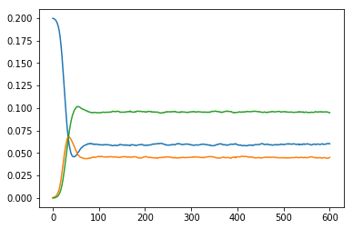

```python
nsimulaciones = 100
max_time=600
C=0.2
L=50
p=0.5
pr=0.1
ps=0.05
periodic = False
longjump = True
normLL = True

np.random.seed(seed=None)  # seed for reproducibility
stats = np.array([],dtype=float)
stats2 = np.array([],dtype=float)
stats3 = np.array([],dtype=float)


tiemposBreak = []
indicesBreak = []

n = 0

while n < nsimulaciones:

    print("Simulacion",str(n+1))
    evolution_infected, evolution_susceptible, evolution_recovered = simulation(max_time, C, L, p, pr, ps, periodic, longjump, normLL)
    if len(evolution_infected) >= max_time:
      if n == 0:
        stats = np.append(stats, evolution_susceptible)
        stats2 = np.append(stats2, evolution_infected)
        stats3 = np.append(stats3, evolution_recovered)
      else:
        stats = np.vstack((stats,evolution_susceptible))
        stats2 = np.vstack((stats2,evolution_infected))
        stats3 = np.vstack((stats3,evolution_recovered))
      n += 1

statsTotal = np.stack((stats,stats2,stats3), axis = 0)

np.save("NEWESs100t600c02l50LJLL", statsTotal)

medias = []
varianzas = []

medias = np.mean(stats, axis=0)
medias2 = np.mean(stats2, axis=0)
medias3 = np.mean(stats3, axis=0)
varianzas = np.std(stats, axis=0)


plt.plot(medias)
plt.plot(medias2)
plt.plot(medias3)
plt.show()
```

### Salida de nuestra simulacion para campo medio con normalizacion L·L

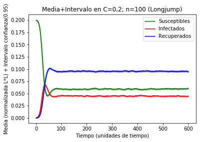

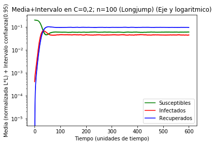

```python
from scipy.stats import distributions as dists
stats4 = collectData("NEWESs100t600c02l50LJLL.npy")


plt.fill_between(range(stats4["s_means"].shape[0]), stats4["s_end"], stats4["s_start"], color='g', alpha=0.5)
plt.fill_between(range(stats4["i_means"].shape[0]), stats4["i_end"], stats4["i_start"], color='r', alpha=0.5)
plt.fill_between(range(stats4["r_means"].shape[0]), stats4["r_end"], stats4["r_start"], color='b', alpha=0.5)
plt.plot(stats4["s_means"], color='g')
plt.plot(stats4["i_means"], color='r')
plt.plot(stats4["r_means"], color='b')
plt.xlabel('Tiempo (unidades de tiempo)')
plt.ylabel('Media (normalizada L*L) + Intervalo confianza(0.95)')
plt.title('Media+Intervalo en C=0,2; n=100 (Longjump)')
plt.legend(['Susceptibles','Infectados', 'Recuperados'])
plt.show()

plt.fill_between(range(stats4["s_means"].shape[0]), stats4["s_end"], stats4["s_start"], color='g', alpha=0.5)
plt.fill_between(range(stats4["i_means"].shape[0]), stats4["i_end"], stats4["i_start"], color='r', alpha=0.5)
plt.fill_between(range(stats4["r_means"].shape[0]), stats4["r_end"], stats4["r_start"], color='b', alpha=0.5)
plt.semilogy(stats4["s_means"], color='g')
plt.semilogy(stats4["i_means"], color='r')
plt.semilogy(stats4["r_means"], color='b')
plt.xlabel('Tiempo (unidades de tiempo)')
plt.ylabel('Media (normalizada L*L) + Intervalo confianza(0.95)')
plt.title('Media+Intervalo en C=0,2; n=100 (Longjump) (Eje y logaritmico)')
plt.legend(['Susceptibles','Infectados', 'Recuperados'])
plt.show()
```

### Comparacion de nuestra simulacion para campo medio con normalizacion L·L

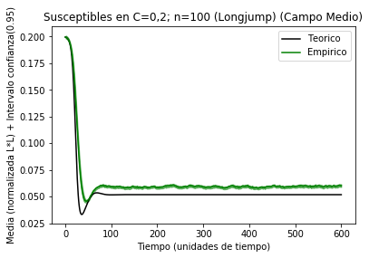

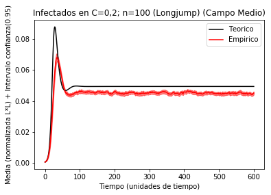

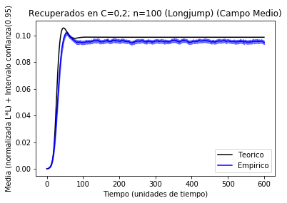

```python
L = 50
C = 0.2
a = pr
b = ps

S = [((L*L*C)-1)/(L*L)]
I = [1/(L*L)]
R = [0]

for t in range(0, max_time):
    S.append(S[t] - S[t]*(1-(1-p*I[t])**4) + b*R[t])

    I.append(I[t] + S[t]*(1-(1-p*I[t])**4) - a*I[t])

    R.append(R[t] + a*I[t] - b*R[t])


plt.plot(S, "k")
plt.fill_between(range(stats4["s_means"].shape[0]), stats4["s_end"], stats4["s_start"], color='g', alpha=0.5)
plt.plot(stats4["s_means"], color='g')
plt.xlabel('Tiempo (unidades de tiempo)')
plt.ylabel('Media (normalizada L*L) + Intervalo confianza(0.95)')
plt.title('Susceptibles en C=0,2; n=100 (Longjump) (Campo Medio)')
plt.legend(['Teorico','Empirico'])
plt.show()

plt.plot(I, "k")
plt.fill_between(range(stats4["i_means"].shape[0]), stats4["i_end"], stats4["i_start"], color='r', alpha=0.5)
plt.plot(stats4["i_means"], color='r')
plt.xlabel('Tiempo (unidades de tiempo)')
plt.ylabel('Media (normalizada L*L) + Intervalo confianza(0.95)')
plt.title('Infectados en C=0,2; n=100 (Longjump) (Campo Medio)')
plt.legend(['Teorico','Empirico'])
plt.show()

plt.plot(R, "k")
plt.fill_between(range(stats4["r_means"].shape[0]), stats4["r_end"], stats4["r_start"], color='b', alpha=0.5)
plt.plot(stats4["r_means"], color='b')
plt.xlabel('Tiempo (unidades de tiempo)')
plt.ylabel('Media (normalizada L*L) + Intervalo confianza(0.95)')
plt.title('Recuperados en C=0,2; n=100 (Longjump) (Campo Medio)')
plt.legend(['Teorico','Empirico'])
plt.show()
```

Como vemos, el resultado no ha cambiado mucho con respecto a la otra normalizacion, asi que hemos tenido que usar otros métodos que se nos ocurrieron más adelante.

Aqui, lo que tenemos es una comparación importante que vimos a la hora de usar los distintos tipos de saltos en el sistema, para ver cual era la verdadera diferencia entre saltos a vecinos y Longjump.

### Comparacion gráficas Longjump vs Saltos a vecinos

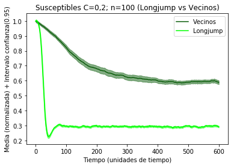

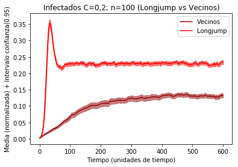

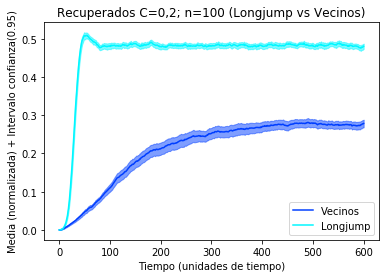

```python
plt.fill_between(range(stats2["s_means"].shape[0]), stats2["s_end"], stats2["s_start"], color='#0B5D0B', alpha=0.5)
plt.plot(stats2["s_means"], color='#0B5D0B')
plt.fill_between(range(stats3["s_means"].shape[0]), stats3["s_end"], stats3["s_start"], color='#00FF00', alpha=0.5)
plt.plot(stats3["s_means"], color='#00FF00')
plt.xlabel('Tiempo (unidades de tiempo)')
plt.ylabel('Media (normalizada) + Intervalo confianza(0.95)')
plt.title('Susceptibles C=0,2; n=100 (Longjump vs Vecinos)')
plt.legend(['Vecinos','Longjump'])
plt.show()


plt.fill_between(range(stats2["i_means"].shape[0]), stats2["i_end"], stats2["i_start"], color='#970404', alpha=0.5)
plt.plot(stats2["i_means"], color='#970404')
plt.fill_between(range(stats3["i_means"].shape[0]), stats3["i_end"], stats3["i_start"], color='#FF0000', alpha=0.5)
plt.plot(stats3["i_means"], color='#FF0000')
plt.xlabel('Tiempo (unidades de tiempo)')
plt.ylabel('Media (normalizada) + Intervalo confianza(0.95)')
plt.title('Infectados C=0,2; n=100 (Longjump vs Vecinos)')
plt.legend(['Vecinos','Longjump'])
plt.show()


plt.fill_between(range(stats2["r_means"].shape[0]), stats2["r_end"], stats2["r_start"], color='#003EFF', alpha=0.5)
plt.plot(stats2["r_means"], color='#003EFF')
plt.fill_between(range(stats3["r_means"].shape[0]), stats3["r_end"], stats3["r_start"], color='#00F7FF', alpha=0.5)
plt.plot(stats3["r_means"], color='#00F7FF')
plt.xlabel('Tiempo (unidades de tiempo)')
plt.ylabel('Media (normalizada) + Intervalo confianza(0.95)')
plt.title('Recuperados C=0,2; n=100 (Longjump vs Vecinos)')
plt.legend(['Vecinos','Longjump'])
plt.show()
```

Como vemos, la diferencia es bastante grande a pesar de que ambos resultados están normalizados con el mismo valor.

Además, la forma es bastante diferente ya que al usar saltos a vecinos seguimos una curva de forma logaritmica, mientras que al usar longjump tenemos una subida (o bajada) inicial muy pronunciada seguida de un máximo (o mínimo) y otra pequeña subida (o bajada) mas leve que acaba en el valor estacionario.

### Tabla valores Longjump vs Campo Medio

```python
from IPython.display import HTML, display
n = 4
Sest = a/(n*p)
Iest = (C - (a/(n*p)))/(1+(a/b))
Rest = (a*(C - (a/(n*p))))/(a+b)


salida = "<table><tr><th>Variable</th><th>Teorico</th><th>Ecuaciones</th><th>Simulado</th><th>Diferencia</th><th>Poblacion dieferencia</th></tr>"
salida += "<tr><td>Susceptibles</td><td>%.4f</td><td>%.4f</td><td>%.4f</td><td>%.4f</td><td>%.4f</td></tr>" % (Sest, S[-1],stats4["s_means"][-1],S[-1]-stats4["s_means"][-1], (S[-1]-stats4["s_means"][-1])*(L*L))
salida += "<tr><td>Infectados</td><td>%.4f</td><td>%.4f</td><td>%.4f</td><td>%.4f</td><td>%.4f</td></tr>" % (Iest, I[-1],stats4["i_means"][-1],I[-1]-stats4["i_means"][-1], (I[-1]-stats4["i_means"][-1])*(L*L))
salida += "<tr><td>Recuperados</td><td>%.4f</td><td>%.4f</td><td>%.4f</td><td>%.4f</td><td>%.4f</td></tr>" % (Rest, R[-1],stats4["r_means"][-1],R[-1]-stats4["r_means"][-1], (R[-1]-stats4["r_means"][-1])*(L*L))
salida += "</table>"
display(HTML(salida))
```

| Variable | Teorico | Ecuaciones | Simulado | Diferencia | Poblacion dieferencia |
| --- | --- | --- | --- | --- | --- |
| Susceptibles | 0.0500 | 0.0519 | 0.0603 | -0.0085 | -21.1252 |
| Infectados | 0.0500 | 0.0494 | 0.0451 | 0.0043 | 10.7851 |
| Recuperados | 0.1000 | 0.0987 | 0.0948 | 0.0039 | 9.8201 |

La tabla está distribuida de la siguiente forma:

```
- Teorico → Nos indica el valor esperado para el estado estacionario según las ecuaciones del paper para el estado                     estacionario.
- Ecuaciones → Nos indica el valor en el estado estacionario para las ecuaciones de campo medio.
- Simulado → Nos indica el valor en el estado estacionario para nuestra simulación.
- Diferencia → Nos indica la diferencia entre el valor de las ecuaciones de campo medio y nuestro valor simulado
- Pobalcion Dieferencia → Nos indica, sabiendo la diferencia, de cuantos nodos de dieferencia aproximadamente hay                                   entre el estado estacionario del campo medio y nuestra simulación.
```

Como hemos mencionado antes, se puede apreciar la diferencia entre los valores de estado estacionario que se apreciaban entre las graficas. Otra de las soluciones propuestas para intentar arreglar esto era cambiar el valor de L a 100, ya que estabamos usando 50 para ahorrar tiempo en las simulaciones.

### Probando con L=100

```
Simulacion 1
Simulacion 2
Simulacion 3
Simulacion 4
Simulacion 5
Simulacion 6
Simulacion 6
Simulacion 6
Simulacion 7
Simulacion 7
Simulacion 8
Simulacion 9
Simulacion 10
Simulacion 11
Simulacion 12
Simulacion 13
Simulacion 14
Simulacion 14
Simulacion 15
Simulacion 16
Simulacion 17
Simulacion 17
Simulacion 18
Simulacion 18
Simulacion 19
Simulacion 20
Simulacion 21
Simulacion 22
Simulacion 23
Simulacion 24
Simulacion 25
Simulacion 26
Simulacion 27
Simulacion 28
Simulacion 28
Simulacion 29
Simulacion 30
Simulacion 31
Simulacion 31
Simulacion 31
```

[output cut: 85 more lines]

```
Simulacion 93
Simulacion 93
Simulacion 94
Simulacion 95
Simulacion 95
Simulacion 96
Simulacion 96
Simulacion 96
Simulacion 97
Simulacion 97
Simulacion 98
Simulacion 99
Simulacion 100
Simulacion 100
Simulacion 100
```

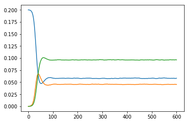

```python
nsimulaciones = 100
max_time=600
C=0.2
L=100
p=0.5
pr=0.1
ps=0.05
periodic = False
longjump = True
normLL = True

np.random.seed(seed=None)  # seed for reproducibility
stats = np.array([],dtype=float)
stats2 = np.array([],dtype=float)
stats3 = np.array([],dtype=float)


tiemposBreak = []
indicesBreak = []

n = 0

while n < nsimulaciones:

    print("Simulacion",str(n+1))
    evolution_infected, evolution_susceptible, evolution_recovered = simulation(max_time, C, L, p, pr, ps, periodic, longjump, normLL)
    if len(evolution_infected) >= max_time:
      if n == 0:
        stats = np.append(stats, evolution_susceptible)
        stats2 = np.append(stats2, evolution_infected)
        stats3 = np.append(stats3, evolution_recovered)
      else:
        stats = np.vstack((stats,evolution_susceptible))
        stats2 = np.vstack((stats2,evolution_infected))
        stats3 = np.vstack((stats3,evolution_recovered))
      n += 1

statsTotal = np.stack((stats,stats2,stats3), axis = 0)

np.save("NEWESs100t600c02l100LJLL", statsTotal)

medias = []
varianzas = []

medias = np.mean(stats, axis=0)
medias2 = np.mean(stats2, axis=0)
medias3 = np.mean(stats3, axis=0)
varianzas = np.std(stats, axis=0)


plt.plot(medias)
plt.plot(medias2)
plt.plot(medias3)
plt.show()
```

### Salida para L = 100

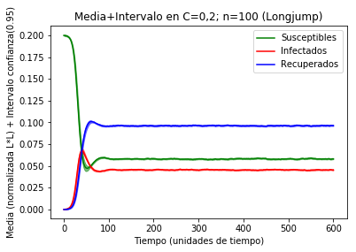

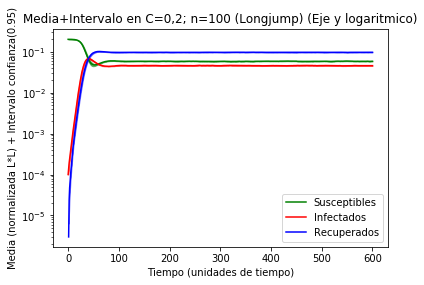

```python
from scipy.stats import distributions as dists
stats5 = collectData("NEWESs100t600c02l100LJLL.npy")


plt.fill_between(range(stats5["s_means"].shape[0]), stats5["s_end"], stats5["s_start"], color='g', alpha=0.5)
plt.fill_between(range(stats5["i_means"].shape[0]), stats5["i_end"], stats5["i_start"], color='r', alpha=0.5)
plt.fill_between(range(stats5["r_means"].shape[0]), stats5["r_end"], stats5["r_start"], color='b', alpha=0.5)
plt.plot(stats5["s_means"], color='g')
plt.plot(stats5["i_means"], color='r')
plt.plot(stats5["r_means"], color='b')
plt.xlabel('Tiempo (unidades de tiempo)')
plt.ylabel('Media (normalizada L*L) + Intervalo confianza(0.95)')
plt.title('Media+Intervalo en C=0,2; n=100 (Longjump)')
plt.legend(['Susceptibles','Infectados', 'Recuperados'])
plt.show()

plt.fill_between(range(stats5["s_means"].shape[0]), stats5["s_end"], stats5["s_start"], color='g', alpha=0.5)
plt.fill_between(range(stats5["i_means"].shape[0]), stats5["i_end"], stats5["i_start"], color='r', alpha=0.5)
plt.fill_between(range(stats5["r_means"].shape[0]), stats5["r_end"], stats5["r_start"], color='b', alpha=0.5)
plt.semilogy(stats5["s_means"], color='g')
plt.semilogy(stats5["i_means"], color='r')
plt.semilogy(stats5["r_means"], color='b')
plt.xlabel('Tiempo (unidades de tiempo)')
plt.ylabel('Media (normalizada L*L) + Intervalo confianza(0.95)')
plt.title('Media+Intervalo en C=0,2; n=100 (Longjump) (Eje y logaritmico)')
plt.legend(['Susceptibles','Infectados', 'Recuperados'])
plt.show()
```

### Comparacion con campo medio para L = 100

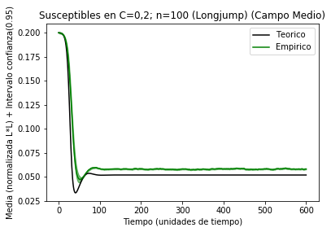

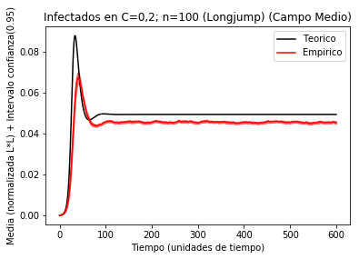

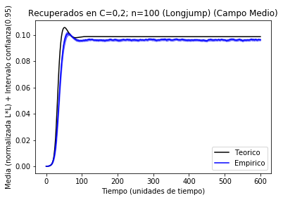

```python
L = 100
C = 0.2
a = pr
b = ps

S = [((L*L*C)-1)/(L*L)]
I = [1/(L*L)]
R = [0]

for t in range(0, max_time):
    S.append(S[t] - S[t]*(1-(1-p*I[t])**4) + b*R[t])

    I.append(I[t] + S[t]*(1-(1-p*I[t])**4) - a*I[t])

    R.append(R[t] + a*I[t] - b*R[t])


plt.plot(S, "k")
plt.fill_between(range(stats5["s_means"].shape[0]), stats5["s_end"], stats5["s_start"], color='g', alpha=0.5)
plt.plot(stats5["s_means"], color='g')
plt.xlabel('Tiempo (unidades de tiempo)')
plt.ylabel('Media (normalizada L*L) + Intervalo confianza(0.95)')
plt.title('Susceptibles en C=0,2; n=100 (Longjump) (Campo Medio)')
plt.legend(['Teorico','Empirico'])
plt.show()

plt.plot(I, "k")
plt.fill_between(range(stats5["i_means"].shape[0]), stats5["i_end"], stats5["i_start"], color='r', alpha=0.5)
plt.plot(stats5["i_means"], color='r')
plt.xlabel('Tiempo (unidades de tiempo)')
plt.ylabel('Media (normalizada L*L) + Intervalo confianza(0.95)')
plt.title('Infectados en C=0,2; n=100 (Longjump) (Campo Medio)')
plt.legend(['Teorico','Empirico'])
plt.show()

plt.plot(R, "k")
plt.fill_between(range(stats5["r_means"].shape[0]), stats5["r_end"], stats5["r_start"], color='b', alpha=0.5)
plt.plot(stats5["r_means"], color='b')
plt.xlabel('Tiempo (unidades de tiempo)')
plt.ylabel('Media (normalizada L*L) + Intervalo confianza(0.95)')
plt.title('Recuperados en C=0,2; n=100 (Longjump) (Campo Medio)')
plt.legend(['Teorico','Empirico'])
plt.show()
```

Como se puede apreciar en las gráficas, los cambios siguen sin afectar al error encontrado previamente.

### Tabla valores L=100 vs Campo medio

```python
from IPython.display import HTML, display
n = 4
Sest = a/(n*p)
Iest = (C - (a/(n*p)))/(1+(a/b))
Rest = (a*(C - (a/(n*p))))/(a+b)


salida = "<table><tr><th>Variable</th><th>Teorico</th><th>Ecuaciones</th><th>Simulado</th><th>Diferencia</th><th>Poblacion dieferencia</th></tr>"
salida += "<tr><td>Susceptibles</td><td>%.4f</td><td>%.4f</td><td>%.4f</td><td>%.4f</td><td>%.4f</td></tr>" % (Sest, S[-1],stats5["s_means"][-1],S[-1]-stats5["s_means"][-1], (S[-1]-stats5["s_means"][-1])*(L*L))
salida += "<tr><td>Infectados</td><td>%.4f</td><td>%.4f</td><td>%.4f</td><td>%.4f</td><td>%.4f</td></tr>" % (Iest, I[-1],stats5["i_means"][-1],I[-1]-stats5["i_means"][-1], (I[-1]-stats5["i_means"][-1])*(L*L))
salida += "<tr><td>Recuperados</td><td>%.4f</td><td>%.4f</td><td>%.4f</td><td>%.4f</td><td>%.4f</td></tr>" % (Rest, R[-1],stats5["r_means"][-1],R[-1]-stats5["r_means"][-1], (R[-1]-stats5["r_means"][-1])*(L*L))
salida += "</table>"
display(HTML(salida))
```

| Variable | Teorico | Ecuaciones | Simulado | Diferencia | Poblacion dieferencia |
| --- | --- | --- | --- | --- | --- |
| Susceptibles | 0.0500 | 0.0519 | 0.0582 | -0.0063 | -62.8907 |
| Infectados | 0.0500 | 0.0494 | 0.0455 | 0.0039 | 38.9302 |
| Recuperados | 0.1000 | 0.0987 | 0.0964 | 0.0023 | 22.9805 |

# Condiciones de entorno periodicas

Como último cambio añadido, probamos añadiendo las condiciones de entorno periódicas a nuestra gráfica, para así hacer que, además de los longjump, cada nodo tuviese el mismo número de vecinos.

```
Simulacion 1
Simulacion 1
Simulacion 2
Simulacion 3
Simulacion 4
Simulacion 4
Simulacion 4
Simulacion 4
Simulacion 5
Simulacion 6
Simulacion 7
Simulacion 8
Simulacion 9
Simulacion 10
Simulacion 10
Simulacion 11
Simulacion 12
Simulacion 13
Simulacion 13
Simulacion 13
Simulacion 13
Simulacion 14
Simulacion 15
Simulacion 16
Simulacion 16
Simulacion 16
Simulacion 17
Simulacion 18
Simulacion 19
Simulacion 20
Simulacion 21
Simulacion 22
Simulacion 23
Simulacion 24
Simulacion 25
Simulacion 26
Simulacion 26
Simulacion 27
Simulacion 28
Simulacion 28
```

[output cut: 21 more lines]

```
Simulacion 39
Simulacion 40
Simulacion 41
Simulacion 42
Simulacion 43
Simulacion 44
Simulacion 45
Simulacion 45
Simulacion 46
Simulacion 46
Simulacion 47
Simulacion 48
Simulacion 49
Simulacion 49
Simulacion 50
```

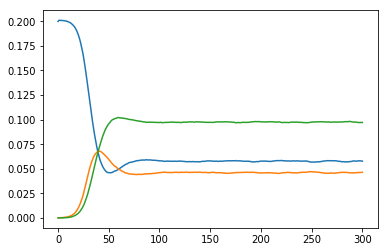

```python
nsimulaciones = 50
max_time=300
C=0.2
L=100
p=0.5
pr=0.1
ps=0.05
periodic = True
longjump = True
normLL = True

np.random.seed(seed=None)  # seed for reproducibility
stats = np.array([],dtype=float)
stats2 = np.array([],dtype=float)
stats3 = np.array([],dtype=float)


tiemposBreak = []
indicesBreak = []

n = 0

while n < nsimulaciones:

    print("Simulacion",str(n+1))
    evolution_infected, evolution_susceptible, evolution_recovered = simulation(max_time, C, L, p, pr, ps, periodic, longjump, normLL)
    if len(evolution_infected) >= max_time:
      if n == 0:
        stats = np.append(stats, evolution_susceptible)
        stats2 = np.append(stats2, evolution_infected)
        stats3 = np.append(stats3, evolution_recovered)
      else:
        stats = np.vstack((stats,evolution_susceptible))
        stats2 = np.vstack((stats2,evolution_infected))
        stats3 = np.vstack((stats3,evolution_recovered))
      n += 1

statsTotal = np.stack((stats,stats2,stats3), axis = 0)

np.save("NEWESs100t600c02l100LJLLPeriodic", statsTotal)

medias = []
varianzas = []

medias = np.mean(stats, axis=0)
medias2 = np.mean(stats2, axis=0)
medias3 = np.mean(stats3, axis=0)
varianzas = np.std(stats, axis=0)


plt.plot(medias)
plt.plot(medias2)
plt.plot(medias3)
plt.show()
```

### Salida simulación condiciones de entorno periódicas

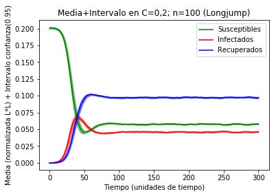

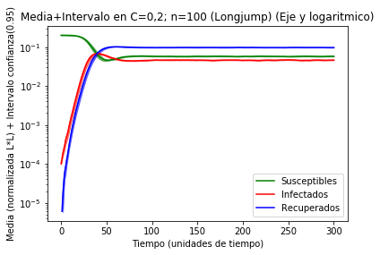

```python
from scipy.stats import distributions as dists
stats6 = collectData("NEWESs100t600c02l100LJLLPeriodic.npy")


plt.fill_between(range(stats6["s_means"].shape[0]), stats6["s_end"], stats6["s_start"], color='g', alpha=0.5)
plt.fill_between(range(stats6["i_means"].shape[0]), stats6["i_end"], stats6["i_start"], color='r', alpha=0.5)
plt.fill_between(range(stats6["r_means"].shape[0]), stats6["r_end"], stats6["r_start"], color='b', alpha=0.5)
plt.plot(stats6["s_means"], color='g')
plt.plot(stats6["i_means"], color='r')
plt.plot(stats6["r_means"], color='b')
plt.xlabel('Tiempo (unidades de tiempo)')
plt.ylabel('Media (normalizada L*L) + Intervalo confianza(0.95)')
plt.title('Media+Intervalo en C=0,2; n=100 (Longjump)')
plt.legend(['Susceptibles','Infectados', 'Recuperados'])
plt.show()

plt.fill_between(range(stats6["s_means"].shape[0]), stats6["s_end"], stats6["s_start"], color='g', alpha=0.5)
plt.fill_between(range(stats6["i_means"].shape[0]), stats6["i_end"], stats6["i_start"], color='r', alpha=0.5)
plt.fill_between(range(stats6["r_means"].shape[0]), stats6["r_end"], stats6["r_start"], color='b', alpha=0.5)
plt.semilogy(stats6["s_means"], color='g')
plt.semilogy(stats6["i_means"], color='r')
plt.semilogy(stats6["r_means"], color='b')
plt.xlabel('Tiempo (unidades de tiempo)')
plt.ylabel('Media (normalizada L*L) + Intervalo confianza(0.95)')
plt.title('Media+Intervalo en C=0,2; n=100 (Longjump) (Eje y logaritmico)')
plt.legend(['Susceptibles','Infectados', 'Recuperados'])
plt.show()
```